# Weather & Airline Delays - Fall’25 Data Wrangling Project

*Each Markdown corresponds to the code above*

## **Data Load:**

```r
# Load required packages
reqs <- c("DBI", "duckdb", "dplyr", "glue", "here")
newp <- reqs[!(reqs %in% installed.packages()[, "Package"])]
if (length(newp)) install.packages(newp)
lapply(reqs, library, character.only = TRUE)
```

```
here() starts at C:/Users/iamab/OneDrive/Documents/UT Austin/Course work/Fall 2025/Data Wrangling/Final Project
```

[output not shown]

```r
# ----------------------------
# Reset database for a clean run
# ----------------------------

if (file.exists("wrangle.duckdb")) {
  file.remove("wrangle.duckdb")
}
```

```
[1] TRUE
```

```r
# Create a fresh DuckDB connection
con <- DBI::dbConnect(duckdb::duckdb(), dbdir = "wrangle.duckdb", read_only = FALSE)

# File paths
noaa_csv <- here("StormEvents_details-ftp_v1.0_d2024_c20250818.csv")
bts_csv  <- here("Airline_Delay_Cause.csv")
airp_csv <- here("airport-codes.csv")

# ----------------------------
# Load raw CSVs into DuckDB tables
# ----------------------------

DBI::dbExecute(con, glue("
  CREATE TABLE storm_events AS
  SELECT * FROM read_csv_auto('{noaa_csv}');
"))
```

```
[1] 69493
```

```r
DBI::dbExecute(con, glue("
  CREATE TABLE airport_codes AS
  SELECT * FROM read_csv_auto('{airp_csv}');
"))
```

```
[1] 82808
```

```r
DBI::dbExecute(con, glue("
  CREATE TABLE airport_delays AS
  SELECT * FROM read_csv_auto('{bts_csv}');
"))
```

```
[1] 22609
```

```r
# Show tables loaded
DBI::dbListTables(con)
```

```
[1] "airport_codes"  "airport_delays" "storm_events"
```

In this section, we load the R packages used throughout the project and define the paths to the three datasets. We also connect to a DuckDB database, which lets us work with the large CSV files efficiently.

This prepares our environment so the remaining steps can pull the data directly from DuckDB instead of reading the CSVs repeatedly.

```r
storm_events      <- DBI::dbReadTable(con, "storm_events")
airport_codes     <- DBI::dbReadTable(con, "airport_codes")
airport_delays    <- DBI::dbReadTable(con, "airport_delays")
```

#### **Importing the DuckDB tables into R**

Here we read each of the three tables stored in DuckDB into R data frames:

- storm_events
- airport_codes
- airport_delays

Having them in R lets us inspect the raw data and run quality checks before doing any cleaning or transformations.

```r
# Simple row counts for QC
library(dplyr)

qc_counts <- tibble(
  table_name = c("storm_events", "airport_codes", "airport_delays"),
  nrows = c(
    nrow(storm_events),
    nrow(airport_codes),
    nrow(airport_delays)
  )
)

qc_counts
```

```
# A tibble: 3 × 2
  table_name     nrows
  <chr>          <int>
1 storm_events   69493
2 airport_codes  82808
3 airport_delays 22609
```

This quick QC step confirms that each table loaded correctly and contains the expected number of rows.  
This provides an early warning if something went wrong in the import step.

```r
#Data Preview

head(storm_events, 3)
```

```
  BEGIN_YEARMONTH BEGIN_DAY BEGIN_TIME END_YEARMONTH END_DAY END_TIME
1          202404        30       2033        202404      30     2033
2          202407         1          0        202407       5      900
3          202411        16        230        202411      18     1421
  EPISODE_ID EVENT_ID     STATE STATE_FIPS YEAR MONTH_NAME        EVENT_TYPE
1     189851  1174463  OKLAHOMA         40 2024      April Thunderstorm Wind
2     193486  1195301 LOUISIANA         22 2024       July    Excessive Heat
3     197838  1223377    OREGON         41 2024   November        Heavy Snow
  CZ_TYPE CZ_FIPS                            CZ_NAME WFO    BEGIN_DATE_TIME
1       C     141                            TILLMAN OUN 30-APR-24 20:33:00
2       Z      18                       NATCHITOCHES SHV 01-JUL-24 00:00:00
3       Z     509 EAST SLOPES OF THE OREGON CASCADES PDT 16-NOV-24 02:30:00
  CZ_TIMEZONE      END_DATE_TIME INJURIES_DIRECT INJURIES_INDIRECT
1       CST-6 30-APR-24 20:33:00               0                 0
2       CST-6 05-JUL-24 09:00:00               0                 0
```

[output cut: 33 more lines]

```r
head(airport_codes, 3)
```

```
  ident          type                 name elevation_ft continent iso_country
1   00A      heliport    Total RF Heliport           11        NA          US
2  00AA small_airport Aero B Ranch Airport         3435        NA          US
3  00AK small_airport         Lowell Field          450        NA          US
  iso_region municipality icao_code iata_code gps_code local_code
1      US-PA     Bensalem      <NA>      <NA>     K00A        00A
2      US-KS        Leoti      <NA>      <NA>     00AA       00AA
3      US-AK Anchor Point      <NA>      <NA>     00AK       00AK
             coordinates
1  40.070985, -74.933689
2 38.704022, -101.473911
3 59.947733, -151.692524
```

```r
head(airport_delays, 3)
```

```
  year month carrier carrier_name airport
1 2024    12      MQ    Envoy Air     EVV
2 2024    12      MQ    Envoy Air     EWR
3 2024    12      MQ    Envoy Air     EYW
                              airport_name arr_flights arr_del15 carrier_ct
1      Evansville, IN: Evansville Regional          61         9       1.52
2 Newark, NJ: Newark Liberty International         107        42       6.01
3     Key West, FL: Key West International         169        31       3.37
  weather_ct nas_ct security_ct late_aircraft_ct arr_cancelled arr_diverted
1       1.08   0.56           0             5.84             0            0
2       5.89  25.16           0             4.94             0            0
3       0.71  11.44           0            15.48             5            3
  arr_delay carrier_delay weather_delay nas_delay security_delay
1       732            47            90        19              0
2      2531           335           491      1251              0
3      1596           143            52       468              0
  late_aircraft_delay
1                 576
2                 454
3                 933
```

Printing the first few rows of each dataset to visually inspect the structure.

```r
airport_delays %>%
  summarise(
    total_weather_ct = sum(weather_ct, na.rm = TRUE),
    total_carrier_ct = sum(carrier_ct, na.rm = TRUE),
    total_nas_ct = sum(nas_ct, na.rm = TRUE),
    total_security_ct = sum(security_ct, na.rm = TRUE),
    total_late_aircraft_ct = sum(late_aircraft_ct, na.rm = TRUE)
  )
```

```
  total_weather_ct total_carrier_ct total_nas_ct total_security_ct
1         57622.19         485820.1     416812.4           3981.78
  total_late_aircraft_ct
1               566841.9
```

Computing simple totals for several delay-related columns. These kinds of summary checks are useful for catching obvious anomalies early.

```r
airport_delays %>%
  summarise(
    total_cancelled = sum(arr_cancelled, na.rm = TRUE),
    total_diverted = sum(arr_diverted, na.rm = TRUE),
    avg_cancelled = mean(arr_cancelled, na.rm = TRUE)
  )
```

```
  total_cancelled total_diverted avg_cancelled
1          102908          18831      4.554862
```

Computing basic totals and averages for cancellations and diversions.  
This provides additional context about how delays and cancellations appear in the raw data and helps verify that these columns contain reasonable values.

## **Data Cleaning:**

```r
library(dplyr)
library(tidyr)   # only if needed for separate(), but not required

airport_codes_clean <- airport_codes %>%
  # keep only US + 3 airport types
  filter(
    iso_country == "US",
    type %in% c("large_airport", "medium_airport", "small_airport")
  ) %>%

  # create new variables
  mutate(
    # choose airport code
    airport_code = case_when(
      !is.na(iata_code) & iata_code != "" ~ iata_code,
      substr(ident, 1, 1) == "K" ~ substr(ident, 2, nchar(ident)),
      TRUE ~ ident
    ),

    # extract state code from iso_region "US-PA" → "PA"
    state = substr(iso_region, 4, 5),

    # latitude and longitude parsed from coordinates column
    lat = as.numeric(sub(",.*", "", coordinates)),          # before the comma
    lon = as.numeric(sub(".*,", "", coordinates))           # after the comma
  ) %>%

  # keep only needed columns
  select(
    airport_code,
    airport_name = name,
    iso_country,
    state,
    city = municipality,
    type,
    elev_ft = elevation_ft,
    lat,
    lon
  )

# preview
head(airport_codes_clean, 10)
```

```
   airport_code            airport_name iso_country state         city
1          00AA    Aero B Ranch Airport          US    KS        Leoti
2          00AK            Lowell Field          US    AK Anchor Point
3          00AL            Epps Airpark          US    AL      Harvest
4          00AN    Katmai Lodge Airport          US    AK  King Salmon
5          00AS          Fulton Airport          US    OK         Alex
6          00AZ          Cordes Airport          US    AZ       Cordes
7          00CA Goldstone (GTS) Airport          US    CA      Barstow
8          00CL     Williams Ag Airport          US    CA        Biggs
9          00FA     Grass Patch Airport          US    FL     Bushnell
10         00FL       River Oak Airport          US    FL   Okeechobee
            type elev_ft      lat        lon
1  small_airport    3435 38.70402 -101.47391
2  small_airport     450 59.94773 -151.69252
3  small_airport     820 34.86480  -86.77030
4  small_airport      80 59.09329 -156.45670
5  small_airport    1100 34.94280  -97.81802
6  small_airport    3810 34.30560 -112.16500
7  small_airport    3038 35.35474 -116.88533
8  small_airport      87 39.42719 -121.76343
9  small_airport      53 28.64550  -82.21900
10 small_airport      35 27.23090  -80.96920
```

We filter the airport list to keep only US airports that are large, medium, or small, since these are the ones relevant for commercial flights. Then we create a consistent airport code by using the IATA code when available, or falling back to the FAA identifier. We also extract the state abbreviation and split the latitude and longitude into numeric values. Finally, we keep only the columns needed for later joins.

```r
library(dplyr)
library(tidyr)

airport_delays_clean <- airport_delays %>%
  # keep only valid rows (same WHERE clause as SQL)
  filter(
    !is.na(year),
    month >= 1 & month <= 12,
    !is.na(arr_flights),
    arr_flights > 0
  ) %>%
  # replace NA in delay-related columns with 0 (simple and taught in class)
  replace_na(list(
    arr_del15        = 0,
    arr_delay        = 0,
    weather_ct       = 0,
    weather_delay    = 0,
    carrier_ct       = 0,
    carrier_delay    = 0,
    arr_cancelled    = 0,
    arr_diverted     = 0
  )) %>%
  mutate(
    yr = as.integer(year),
    mth = as.integer(month),
    airport_code = airport,
    flights = arr_flights,

    delayed_flights     = arr_del15,
    delay_mins          = arr_delay,
    weather_delay_mins  = weather_delay,
    carrier_delay_mins  = carrier_delay,
    cancelled           = arr_cancelled,
    diverted            = arr_diverted
  ) %>%
  select(
    yr, mth, airport_code, flights,
    delayed_flights, delay_mins,
    weather_ct, weather_delay_mins,
    carrier_ct, carrier_delay_mins,
    cancelled, diverted
  )

head(airport_delays_clean, 10)
```

```
     yr mth airport_code flights delayed_flights delay_mins weather_ct
1  2024  12          EVV      61               9        732       1.08
2  2024  12          EWR     107              42       2531       5.89
3  2024  12          EYW     169              31       1596       0.71
4  2024  12          FAR     171              35       2428       2.12
5  2024  12          FSD      69              14        720       2.47
6  2024  12          FSM      91              11        703       0.94
7  2024  12          FWA      90              16        864       1.45
8  2024  12          GCK      61              10        982       1.17
9  2024  12          GJT      73              15        992       0.26
10 2024  12          GNV      47               8        419       0.00
   weather_delay_mins carrier_ct carrier_delay_mins cancelled diverted
1                  90       1.52                 47         0        0
2                 491       6.01                335         0        0
3                  52       3.37                143         5        3
4                 184       4.64                245         2        0
5                 154       2.00                 86         1        0
6                  70       1.40                 80         1        0
7                  64       4.33                120         0        0
8                  67       3.95                202         1        1
9                  64       3.88                141         0        0
10                  0       1.44                106         0        0
```

We first filter the delay dataset to keep only valid records, such as months between 1 and 12 and flights with a positive number of arrivals. Several delay related fields contain missing values, so we replace those NAs with zero using `replace_na`. After that we create cleaner variable names for year, month, airport code, and flight counts, and reorganize the columns we will need later in the analysis.

```r
library(dplyr)

storm_events_clean <- storm_events %>%
  # create year and month (SQL: CAST(BEGIN_YEARMONTH/100))
  mutate(
    yr = as.integer(BEGIN_YEARMONTH %/% 100),
    mth = as.integer(BEGIN_YEARMONTH %% 100)
  ) %>%
  # match WHERE clause
  filter(
    !is.na(STATE),
    !is.na(BEGIN_YEARMONTH),
    BEGIN_YEARMONTH >= 200001,
    BEGIN_YEARMONTH <= 203012
  ) %>%
  # keep only needed columns, rename lat/lon
  select(
    EVENT_ID,
    EPISODE_ID,
    STATE,
    STATE_FIPS,
    yr,
    mth,
    EVENT_TYPE,
    CZ_TYPE,
    CZ_NAME,
    lat = BEGIN_LAT,
    lon = BEGIN_LON,
    INJURIES_DIRECT,
    DEATHS_DIRECT,
    DAMAGE_PROPERTY
  )

# sample rows
head(storm_events_clean, 10)
```

```
   EVENT_ID EPISODE_ID       STATE STATE_FIPS   yr mth        EVENT_TYPE
1   1174463     189851    OKLAHOMA         40 2024   4 Thunderstorm Wind
2   1195301     193486   LOUISIANA         22 2024   7    Excessive Heat
3   1223377     197838      OREGON         41 2024  11        Heavy Snow
4   1184135     191723       TEXAS         48 2024   5              Heat
5   1184133     191723       TEXAS         48 2024   5              Heat
6   1182348     191916 MISSISSIPPI         28 2024   5 Thunderstorm Wind
7   1221908     197531  WASHINGTON         53 2024  11        Heavy Snow
8   1221909     197530      OREGON         41 2024  11        Heavy Snow
9   1181506     191820 MISSISSIPPI         28 2024   5              Hail
10  1181499     191821   TENNESSEE         47 2024   5              Hail
   CZ_TYPE                              CZ_NAME     lat     lon INJURIES_DIRECT
1        C                              TILLMAN 34.3444 -98.983               0
2        Z                         NATCHITOCHES      NA      NA               0
3        Z   EAST SLOPES OF THE OREGON CASCADES      NA      NA               0
```

[output cut: 18 more lines]

We extract the year and month from the `BEGIN_YEARMONTH` field and then filter out records that fall outside the valid date range or have missing state information. After applying these conditions, we keep only the subset of columns needed for later joins and analysis, including identifiers, event metadata, and basic location fields like latitude and longitude. This produces a streamlined storm events table that is easier to work with in the next steps.

```r
storm_events_clean %>%
  summarise(
    n_rows = n(),
    distinct_events = n_distinct(EVENT_ID),
    distinct_episodes = n_distinct(EPISODE_ID)
  )
```

```
  n_rows distinct_events distinct_episodes
1  69493           69493              9861
```

As a quick quality check, we verify the size and structure of the cleaned storm events dataset. This helps confirm that the cleaning steps did not accidentally drop too many records and that the dataset still contains the expected variety of storm events.

```r
library(dplyr)

storm_events_clean %>%
  group_by(yr, mth, STATE) %>%
  summarise(
    n = n(),
    .groups = "drop"
  ) %>%
  arrange(yr, mth, STATE) %>%
  head(20)
```

```
# A tibble: 20 × 4
      yr   mth STATE                    n
   <int> <int> <chr>                <int>
 1  2024     1 ALABAMA                148
 2  2024     1 ALASKA                  67
 3  2024     1 AMERICAN SAMOA           8
 4  2024     1 ARIZONA                 25
 5  2024     1 ARKANSAS               229
 6  2024     1 ATLANTIC NORTH          14
 7  2024     1 ATLANTIC SOUTH          35
 8  2024     1 CALIFORNIA             402
 9  2024     1 COLORADO               166
10  2024     1 CONNECTICUT             27
11  2024     1 DELAWARE                23
12  2024     1 DISTRICT OF COLUMBIA     5
13  2024     1 FLORIDA                199
14  2024     1 GEORGIA                143
15  2024     1 GUAM                     7
16  2024     1 GULF OF MEXICO          51
17  2024     1 HAWAII                  36
18  2024     1 IDAHO                   86
19  2024     1 ILLINOIS               353
20  2024     1 INDIANA                147
```

To understand the distribution of storm events across time and location, we group the cleaned dataset by **year**, **month**, and **state**.

For each combination, we count how many storm records appear.

This gives an early look at temporal and geographic patterns in the raw storm data and helps confirm that monthly reporting is consistent across states. The table below shows the first 20 grouped results.

## **Aggregations and Trending:**

```r
library(dplyr)

monthly_totals <- airport_delays_clean %>%
  group_by(yr, mth) %>%
  summarise(
    total_flights = sum(flights, na.rm = TRUE),
    total_delayed = sum(delayed_flights, na.rm = TRUE),

    pct_delayed = round(
      (sum(delayed_flights, na.rm = TRUE) * 100) /
        ifelse(sum(flights, na.rm = TRUE) == 0, NA, sum(flights, na.rm = TRUE)),
      2
    ),

    avg_delay_mins = round(
      mean(delay_mins, na.rm = TRUE),
      2
    ),

    pct_weather_delay = round(
      (sum(weather_delay_mins, na.rm = TRUE) * 100) /
        ifelse(sum(delay_mins, na.rm = TRUE) == 0, NA, sum(delay_mins, na.rm = TRUE)),
      2
    ),

    .groups = "drop"
  ) %>%
  arrange(yr, mth)

head(monthly_totals)
```

```
# A tibble: 6 × 7
     yr   mth total_flights total_delayed pct_delayed avg_delay_mins
  <int> <int>         <dbl>         <dbl>       <dbl>          <dbl>
1  2024     1        582425        134575        23.1          5468.
2  2024     2        552691         86079        15.6          3003.
3  2024     3        628786        127248        20.2          4784.
4  2024     4        619920        115828        18.7          4314.
5  2024     5        649428        166497        25.6          6762.
6  2024     6        651799        157404        24.2          6057.
# ℹ 1 more variable: pct_weather_delay <dbl>
```

In this step, we aggregate the cleaned airport delay data at the **year–month** level.  
This gives us a national view of flight patterns and delay behavior over time.

For each month, we calculate:

These metrics help identify broader seasonal trends such as busier months, higher delay periods, and the impact of weather on operational performance.

The preview shows the first few months after summarizing.

```r
top10_airports <- airport_delays_clean %>%
  group_by(airport_code) %>%
  summarise(
    total_flights = sum(flights, na.rm = TRUE),
    total_delayed = sum(delayed_flights, na.rm = TRUE),
    pct_delayed = round(
      (total_delayed * 100) /
        ifelse(total_flights == 0, NA, total_flights),
      2
    ),
    .groups = "drop"
  ) %>%
  arrange(desc(total_flights)) %>%
  head(10)

top10_airports
```

```
# A tibble: 10 × 4
   airport_code total_flights total_delayed pct_delayed
   <chr>                <dbl>         <dbl>       <dbl>
 1 ATL                 342538         58817        17.2
 2 ORD                 318122         65018        20.4
 3 DFW                 315680         74664        23.6
 4 DEN                 313280         57607        18.4
 5 CLT                 252408         53683        21.3
 6 LAX                 196159         37409        19.1
 7 PHX                 195141         36587        18.8
 8 LAS                 190775         42105        22.1
 9 SEA                 184912         35033        19.0
10 IAH                 168019         31870        19.0
```

#### Top 10 Busiest Airports by Flight Volume

To understand where the highest concentration of U.S. air traffic occurs, we aggregate the cleaned delay data at the **airport level**.

For each airport, we calculate:

- **Total flights** — all arriving flights recorded in 2024
- **Total delayed flights** — how many of those were delayed
- **Percent delayed** — the share of delayed flights out of all arrivals

After computing these metrics, we sort airports by total flights and display the **top 10 busiest airports**.  
This helps highlight major national hubs and gives context for overall congestion and delay patterns.

The resulting table shows which airports handle the most traffic and how often delays occur at each.

```r
avg_delay_by_airport <- airport_delays_clean %>%
  group_by(airport_code) %>%
  summarise(
    avg_delay_mins = round(mean(delay_mins, na.rm = TRUE), 2),
    avg_weather_delay_mins = round(mean(weather_delay_mins, na.rm = TRUE), 2),
    .groups = "drop"
  ) %>%
  arrange(desc(avg_delay_mins)) %>%
  head(10)

avg_delay_by_airport
```

```
# A tibble: 10 × 3
   airport_code avg_delay_mins avg_weather_delay_mins
   <chr>                 <dbl>                  <dbl>
 1 DFW                  46439.                  4179.
 2 DEN                  32942.                  1847.
 3 ORD                  30557.                  2108.
 4 CLT                  27148.                  1525.
 5 MCO                  26993.                   876.
 6 ATL                  26698.                  1429.
 7 DAL                  24311.                   845.
 8 SFO                  21573.                   914.
 9 JFK                  20785.                   918.
10 SFB                  19891.                  1442.
```

#### Airports With the Highest Average Delay Minutes

In this step, we analyze **how severe delays are at each airport**, not just how often they occur.

For every airport, we calculate:

We then sort airports by *average total delay minutes* in descending order and list the **top 10 airports with the longest delays**.

This highlights which airports tend to experience the most significant disruptions, offering insight into operational bottlenecks and locations where delays accumulate the most.

```r
monthly_avg_delay_per_flight <- airport_delays_clean %>%
  mutate(
    delay_per_flight = ifelse(flights == 0, NA, delay_mins / flights)
  ) %>%
  group_by(airport_code, yr, mth) %>%
  summarise(
    avg_delay_per_flight = round(mean(delay_per_flight, na.rm = TRUE), 2),
    .groups = "drop"
  ) %>%
  arrange(airport_code, yr, mth)

head(monthly_avg_delay_per_flight)
```

```
# A tibble: 6 × 4
  airport_code    yr   mth avg_delay_per_flight
  <chr>        <int> <int>                <dbl>
1 ABE           2024     1                16.3
2 ABE           2024     2                12.3
3 ABE           2024     3                 9.69
4 ABE           2024     4                15.7
5 ABE           2024     5                30.9
6 ABE           2024     6                16.1
```

#### Monthly Average Delay Per Flight

Here we compute **how much delay each flight experiences on average**, by airport and by month.  
We first calculate delay per flight, then take the monthly average for each airport.  
This helps reveal airports and months where delays were especially severe on a per-flight basis.

```r
carrier_level_delays <- airport_delays_clean %>%
  group_by(yr, mth) %>%
  summarise(
    total_carrier_delays = sum(carrier_ct, na.rm = TRUE),
    avg_carrier_delay_mins = round(
      ifelse(
        sum(carrier_ct, na.rm = TRUE) == 0,
        NA,
        sum(carrier_delay_mins, na.rm = TRUE) / sum(carrier_ct, na.rm = TRUE)
      ),
      2
    ),
    .groups = "drop"
  ) %>%
  arrange(yr, mth)

head(carrier_level_delays)
```

```
# A tibble: 6 × 4
     yr   mth total_carrier_delays avg_carrier_delay_mins
  <int> <int>                <dbl>                  <dbl>
1  2024     1               40802.                   81.3
2  2024     2               27852.                   71.2
3  2024     3               37667.                   76.1
4  2024     4               36045.                   74.1
5  2024     5               47615.                   79.8
6  2024     6               50697.                   78.3
```

#### Carrier-Level Delay Patterns

In this step, we summarize **how airline carrier issues contribute to delays** each month.  
We calculate:

- **Total carrier delay incidents**
- **Average minutes of carrier delay per incident**

This helps identify months where airline operational problems (rather than weather or NAS issues) played a larger role in overall delays.

**Joining Airport delays with stroms**

```r
airport_delay_summary <- airport_delays_clean %>%
  inner_join(airport_codes_clean, by = "airport_code") %>%
  group_by(yr, mth, state) %>%
  summarise(
    total_flights = sum(flights, na.rm = TRUE),
    total_delayed = sum(delayed_flights, na.rm = TRUE),
    pct_delayed = round(
      (sum(delayed_flights, na.rm = TRUE) * 100) /
        ifelse(sum(flights, na.rm = TRUE) == 0, NA, sum(flights, na.rm = TRUE)),
      2
    ),
    total_delay_mins = sum(delay_mins, na.rm = TRUE),
    avg_delay_per_flight = round(
      sum(delay_mins, na.rm = TRUE) /
        ifelse(sum(flights, na.rm = TRUE) == 0, NA, sum(flights, na.rm = TRUE)),
      2
    ),
    weather_ct = sum(weather_ct, na.rm = TRUE),
    weather_delay_mins = sum(weather_delay_mins, na.rm = TRUE),
    carrier_ct = sum(carrier_ct, na.rm = TRUE),
    carrier_delay_mins = sum(carrier_delay_mins, na.rm = TRUE),
    .groups = "drop"
  ) %>%
  arrange(yr, mth, state)

head(airport_delay_summary)
```

```
# A tibble: 6 × 12
     yr   mth state total_flights total_delayed pct_delayed total_delay_mins
  <int> <int> <chr>         <dbl>         <dbl>       <dbl>            <dbl>
1  2024     1 AK             3046           850        27.9            57723
2  2024     1 AL             3050           724        23.7            55334
3  2024     1 AR             2347           587        25.0            44662
4  2024     1 AZ            18014          3792        21.0           305105
5  2024     1 CA            58263         11646        20.0           730846
6  2024     1 CO            28653          5863        20.5           462170
# ℹ 5 more variables: avg_delay_per_flight <dbl>, weather_ct <dbl>,
#   weather_delay_mins <dbl>, carrier_ct <dbl>, carrier_delay_mins <dbl>
```

#### State-Month Delay Summary

We join airport delay data with airport metadata and aggregate by **state, year, and month**.  
This produces a clean summary of flights, delays, and delay causes that we will later compare with storm activity.

```r
n_rows_airport_delay_summary <- airport_delay_summary %>%
  summarise(n_rows = n())

n_rows_airport_delay_summary
```

```
# A tibble: 1 × 1
  n_rows
   <int>
1    600
```

```r
n_states <- airport_delay_summary %>%
  summarise(n_states = n_distinct(state))

n_states
```

```
# A tibble: 1 × 1
  n_states
     <int>
1       50
```

#### Summary Checks

We perform a quick validation of the aggregated airport delay table by confirming:

1. **Total number of state–month records**, and
2. **How many unique states appear** in the summary.

These checks help ensure that the join and grouping steps produced complete and expected coverage across all states and months.

```r
state_map <- tibble::tibble(
  full_name = c(
    "ALABAMA","ALASKA","ARIZONA","ARKANSAS","CALIFORNIA","COLORADO","CONNECTICUT",
    "DELAWARE","FLORIDA","GEORGIA","HAWAII","IDAHO","ILLINOIS","INDIANA","IOWA",
    "KANSAS","KENTUCKY","LOUISIANA","MAINE","MARYLAND","MASSACHUSETTS","MICHIGAN",
    "MINNESOTA","MISSISSIPPI","MISSOURI","MONTANA","NEBRASKA","NEVADA",
    "NEW HAMPSHIRE","NEW JERSEY","NEW MEXICO","NEW YORK","NORTH CAROLINA",
    "NORTH DAKOTA","OHIO","OKLAHOMA","OREGON","PENNSYLVANIA","RHODE ISLAND",
    "SOUTH CAROLINA","SOUTH DAKOTA","TENNESSEE","TEXAS","UTAH","VERMONT",
    "VIRGINIA","WASHINGTON","WEST VIRGINIA","WISCONSIN","WYOMING",
    "DISTRICT OF COLUMBIA","PUERTO RICO","AMERICAN SAMOA","GUAM",
    "VIRGIN ISLANDS","NORTHERN MARIANA ISLANDS"
  ),
  code = c(
    "AL","AK","AZ","AR","CA","CO","CT","DE","FL","GA","HI","ID","IL","IN","IA",
    "KS","KY","LA","ME","MD","MA","MI","MN","MS","MO","MT","NE","NV","NH","NJ",
    "NM","NY","NC","ND","OH","OK","OR","PA","RI","SC","SD","TN","TX","UT","VT",
    "VA","WA","WV","WI","WY","DC","PR","AS","GU","VI","MP"
  )
)
```

#### Creating a State Lookup Table

The raw storm data reports states using full names, while our airport dataset uses two letter state codes.  
To make these datasets compatible for joining, we build a **manual state reference table** that maps each full state or territory name to its standard code.

This lookup table allows us to merge storm events with airport level summaries consistently across all US states and territories.

```r
storm_mapped <- storm_events_clean %>%
  # clean state name like SQL: TRIM(UPPER(STATE))
  mutate(
    state_name = toupper(trimws(STATE))
  ) %>%

  # remove ocean / water / lake regions
  filter(
    !grepl("LAKE", state_name),
    !grepl("WATER", state_name),
    !grepl("WATERS", state_name),
    !grepl("ATLANTIC", state_name),
    !grepl("GULF", state_name),
    !grepl("PACIFIC", state_name),
    !grepl("^ST LAWRENCE", state_name)
  ) %>%

  # join with state_map (after uppercasing full_name to match)
  left_join(
    state_map %>%
      mutate(full_name = toupper(full_name)),
    by = c("state_name" = "full_name")
  ) %>%

  # final column selection matching SQL output
  select(
    EVENT_ID,
    EPISODE_ID,
    state_name,
    state = code,
    yr,
    mth,
    EVENT_TYPE,
    lat,
    lon
  )
# preview
head(storm_mapped)
```

```
  EVENT_ID EPISODE_ID  state_name state   yr mth        EVENT_TYPE     lat
1  1174463     189851    OKLAHOMA    OK 2024   4 Thunderstorm Wind 34.3444
2  1195301     193486   LOUISIANA    LA 2024   7    Excessive Heat      NA
3  1223377     197838      OREGON    OR 2024  11        Heavy Snow      NA
4  1184135     191723       TEXAS    TX 2024   5              Heat      NA
5  1184133     191723       TEXAS    TX 2024   5              Heat      NA
6  1182348     191916 MISSISSIPPI    MS 2024   5 Thunderstorm Wind 34.1800
      lon
1 -98.983
2      NA
3      NA
4      NA
5      NA
6 -89.030
```

#### Mapping Storm Events to States

We standardize storm event state names, remove non state regions like lakes and oceans, and join them to our state lookup table.  
This gives each storm event a valid two letter state code so it can be matched with airport delay data.

```r
# count unmapped (state = NA)
unmapped_count <- storm_mapped %>%
  filter(is.na(state)) %>%
  summarise(unmapped = n())

unmapped_count
```

```
  unmapped
1        0
```

```r
# sample unmapped state names (up to 50)
unmapped_examples <- storm_mapped %>%
  filter(is.na(state)) %>%
  distinct(state_name) %>%
  head(50)

unmapped_examples
```

```
[1] state_name
<0 rows> (or 0-length row.names)
```

#### Checking for Unmapped States

After joining storm events to our state lookup table, we verify that all events received a valid state code.  
This step identifies any remaining entries that failed to map correctly, which could signal spelling issues or unexpected region names.

```r
storm_summary <- storm_mapped %>%
  filter(!is.na(state)) %>%
  group_by(yr, mth, state) %>%
  summarise(
    storm_events  = n_distinct(EVENT_ID),
    storm_systems = n_distinct(EPISODE_ID)
  ) %>%
  arrange(yr, mth, state)
# preview
head(storm_summary)
```

```
# A tibble: 6 × 5
# Groups:   yr, mth [1]
     yr   mth state storm_events storm_systems
  <int> <int> <chr>        <int>         <int>
1  2024     1 AK              67            25
2  2024     1 AL             148            13
3  2024     1 AR             229            28
4  2024     1 AS               8             2
5  2024     1 AZ              25             9
6  2024     1 CA             402            61
```

### Summarizing Storm Activity by Year, Month, and State

Now that each storm event has a valid state code, we aggregate the data to understand overall storm activity.  
For every state in each month, we compute:

- the number of unique storm **events**, and
- the number of distinct storm **systems** (episodes)

This produces a clean state–month summary that we can later join to the flight delay data.

```r
# a) overall row count
rows_summary <- storm_summary %>%
  summarise(rows_summary = n())
```

[output not shown]

```r
rows_summary
```

```
# A tibble: 12 × 3
# Groups:   yr [1]
      yr   mth rows_summary
   <int> <int>        <int>
 1  2024     1           55
 2  2024     2           53
 3  2024     3           52
 4  2024     4           54
 5  2024     5           53
 6  2024     6           53
 7  2024     7           53
 8  2024     8           53
 9  2024     9           48
10  2024    10           44
11  2024    11           52
12  2024    12           53
```

```r
# b) sample rows (first 20 ordered by yr, mth, state)
storm_summary_sample <- storm_summary %>%
  arrange(yr, mth, state) %>%
  head(20)

storm_summary_sample
```

```
# A tibble: 20 × 5
# Groups:   yr, mth [1]
      yr   mth state storm_events storm_systems
   <int> <int> <chr>        <int>         <int>
 1  2024     1 AK              67            25
 2  2024     1 AL             148            13
 3  2024     1 AR             229            28
 4  2024     1 AS               8             2
 5  2024     1 AZ              25             9
 6  2024     1 CA             402            61
 7  2024     1 CO             166            25
 8  2024     1 CT              27            12
 9  2024     1 DC               5             5
10  2024     1 DE              23             8
11  2024     1 FL             199            13
12  2024     1 GA             143            11
13  2024     1 GU               7             3
14  2024     1 HI              36             4
15  2024     1 IA             425            22
16  2024     1 ID              86            15
17  2024     1 IL             353            28
18  2024     1 IN             147            21
19  2024     1 KS             195            19
20  2024     1 KY             175            20
```

```r
# c) check a few states (NC, TX, FL)
storm_summary_selected_states <- storm_summary %>%
  filter(state %in% c("NC", "TX", "FL")) %>%
  arrange(yr, mth)

storm_summary_selected_states
```

```
# A tibble: 35 × 5
# Groups:   yr, mth [12]
      yr   mth state storm_events storm_systems
   <int> <int> <chr>        <int>         <int>
 1  2024     1 FL             199            13
 2  2024     1 NC             289            26
 3  2024     1 TX             506            53
 4  2024     2 FL              37             9
 5  2024     2 NC               8             4
 6  2024     2 TX             213            41
 7  2024     3 FL              40            11
 8  2024     3 NC              12             2
 9  2024     3 TX             242            49
10  2024     4 FL             145            14
# ℹ 25 more rows
```

#### Quality Checks on the Storm Summary

To validate that our storm aggregation worked correctly, we perform three simple checks:

1. **Row Count** – confirm the expected number of state–month combinations.
2. **Sample Output** – inspect the first few grouped rows to ensure event counts look reasonable.
3. **State Spot-Check** – review selected states (NC, TX, FL) across all months to confirm that grouping and ordering behave as expected.

These checks help ensure our storm summary is complete and accurately structured before joining it with the flight delay data.

```r
final_joined_table <- airport_delay_summary %>%
  left_join(
    storm_summary,
    by = c("yr", "mth", "state")
  ) %>%
  mutate(
    storm_events  = ifelse(is.na(storm_events), 0, storm_events),
    storm_systems = ifelse(is.na(storm_systems), 0, storm_systems),
    storm_flag    = ifelse(storm_events > 0, 1, 0)
  )

# preview
head(final_joined_table)
```

```
# A tibble: 6 × 15
     yr   mth state total_flights total_delayed pct_delayed total_delay_mins
  <int> <int> <chr>         <dbl>         <dbl>       <dbl>            <dbl>
1  2024     1 AK             3046           850        27.9            57723
2  2024     1 AL             3050           724        23.7            55334
3  2024     1 AR             2347           587        25.0            44662
4  2024     1 AZ            18014          3792        21.0           305105
5  2024     1 CA            58263         11646        20.0           730846
6  2024     1 CO            28653          5863        20.5           462170
# ℹ 8 more variables: avg_delay_per_flight <dbl>, weather_ct <dbl>,
#   weather_delay_mins <dbl>, carrier_ct <dbl>, carrier_delay_mins <dbl>,
#   storm_events <dbl>, storm_systems <dbl>, storm_flag <dbl>
```

#### Joining Flight Delays with Storm Activity

In this step, we merge our monthly airport delay summary with the storm summary. The join uses `yr`, `mth`, and `state` so each state–month receives the correct storm information.  
Any months without storms will naturally have missing values after the join, so we replace those `NA` entries with zero to indicate no storm activity.  
Finally, we create a simple `storm_flag` that marks whether a state–month experienced at least one storm event. This prepares the dataset for comparing delay patterns between storm and non-storm periods.

```r
storm_flag_distribution <- final_joined_table %>%
  filter(storm_flag == 0) %>%
  group_by(storm_flag, state, mth) %>%
  summarise(n = n()) %>%
  ungroup()
storm_flag_distribution
```

```
# A tibble: 23 × 4
   storm_flag state   mth     n
        <dbl> <chr> <int> <int>
 1          0 CT        9     1
 2          0 CT       10     1
 3          0 DC        2     1
 4          0 DC        5     1
 5          0 DC        6     1
 6          0 DC       10     1
 7          0 DC       11     1
 8          0 MA        9     1
 9          0 MA       10     1
10          0 ME        9     1
# ℹ 13 more rows
```

#### **Checking Where No Storms Occurred**

Before moving into visuals, we briefly inspect which state-month combinations had **no recorded storms**.  
Filtering for `storm_flag == 0` and counting these cases helps confirm that our joining logic worked and that non-storm months are correctly represented in the data.

```r
final_joined_table_sample <- final_joined_table %>%
  arrange(yr, mth, state) %>%
  head(20)

final_joined_table_sample
```

```
# A tibble: 20 × 15
      yr   mth state total_flights total_delayed pct_delayed total_delay_mins
   <int> <int> <chr>         <dbl>         <dbl>       <dbl>            <dbl>
 1  2024     1 AK             3046           850        27.9            57723
 2  2024     1 AL             3050           724        23.7            55334
 3  2024     1 AR             2347           587        25.0            44662
 4  2024     1 AZ            18014          3792        21.0           305105
 5  2024     1 CA            58263         11646        20.0           730846
 6  2024     1 CO            28653          5863        20.5           462170
 7  2024     1 CT             1703           481        28.2            33709
 8  2024     1 DC            11718          2645        22.6           228241
 9  2024     1 FL            56535         15592        27.6          1087171
10  2024     1 GA            28469          5895        20.7           482444
11  2024     1 HI            10754          2833        26.3           129104
12  2024     1 IA             2162           589        27.2            54511
13  2024     1 ID             2778           600        21.6            43855
14  2024     1 IL            30261          7525        24.9           702175
15  2024     1 IN             4826          1172        24.3            92086
16  2024     1 KS             1314           339        25.8            27998
17  2024     1 KY             5945          1371        23.1           106010
18  2024     1 LA             5795          1537        26.5           105652
19  2024     1 MA            10335          2575        24.9           202008
20  2024     1 MD             7689          1646        21.4            97783
# ℹ 8 more variables: avg_delay_per_flight <dbl>, weather_ct <dbl>,
#   weather_delay_mins <dbl>, carrier_ct <dbl>, carrier_delay_mins <dbl>,
#   storm_events <dbl>, storm_systems <dbl>, storm_flag <dbl>
```

#### **Previewing the Final Joined Table**

To verify that the merged dataset looks correct, we display the first 20 rows after ordering by year, month, and state.  
This quick check helps ensure that airport delay metrics and storm information now align properly for each state-month combination.

### **Visualization Summaries**

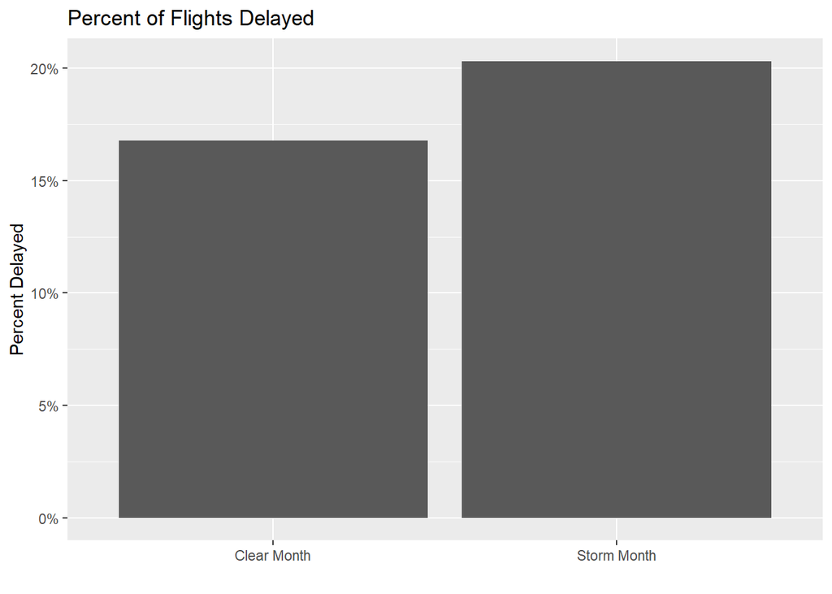

```r
# national summary
national_summary <- final_joined_table %>%
  group_by(storm_flag) %>%
  summarise(
    flights = sum(total_flights, na.rm = TRUE),
    delayed = sum(total_delayed, na.rm = TRUE),
    pct_delayed = sum(total_delayed, na.rm = TRUE) / sum(total_flights, na.rm = TRUE),
    total_delay_mins = sum(total_delay_mins, na.rm = TRUE),
    avg_delay_per_flight = total_delay_mins / sum(total_flights, na.rm = TRUE),
    n_state_months = n()
  ) %>%
  mutate(
    storm_flag = factor(storm_flag, labels = c("Clear Month", "Storm Month"))
  )


library(ggplot2)

# 1. Percent delayed bar chart (with percent formatting)
ggplot(national_summary, aes(x = storm_flag, y = pct_delayed)) +
  geom_col() +
  scale_y_continuous(labels = scales::percent_format(accuracy = 1)) +
  labs(
    title = "Percent of Flights Delayed",
    x = "",
    y = "Percent Delayed"
  )
```

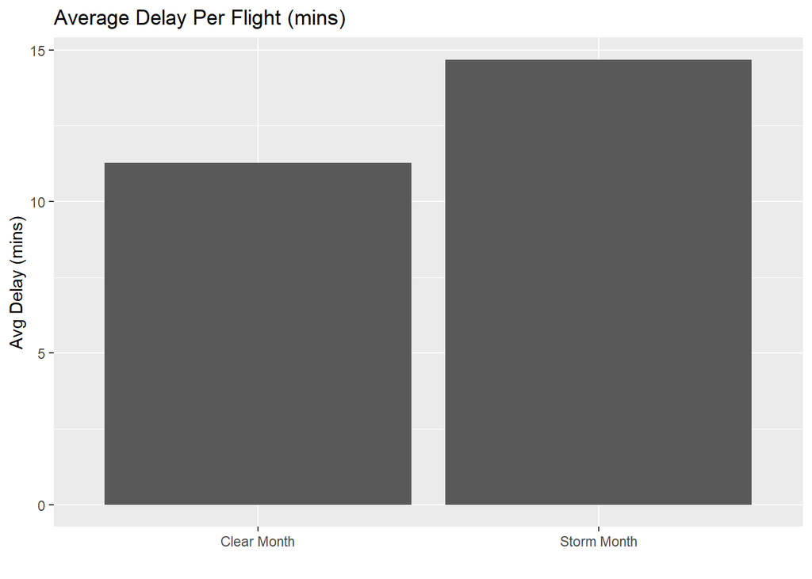

```r
# 2. Avg delay per flight bar chart
ggplot(national_summary, aes(x = storm_flag, y = avg_delay_per_flight)) +
  geom_col() +
  labs(
    title = "Average Delay Per Flight (mins)",
    x = "",
    y = "Avg Delay (mins)"
  )
```

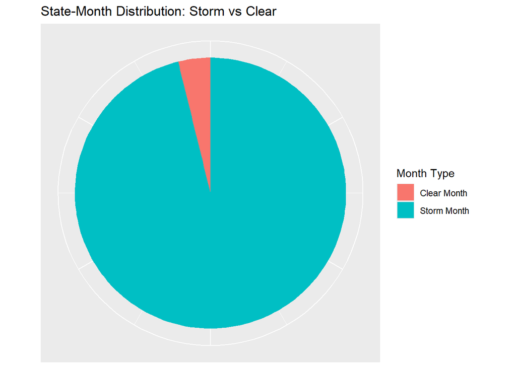

```r
# 3. Pie chart with proper legend
ggplot(national_summary, aes(x = "", y = n_state_months, fill = storm_flag)) +
  geom_col(width = 1) +
  coord_polar("y") +
  labs(
    title = "State-Month Distribution: Storm vs Clear",
    fill = "Month Type"
  ) +
  theme(
    axis.text = element_blank(),
    axis.title = element_blank(),
    axis.ticks = element_blank()
  )
```

### **National Delay Summary**

To understand how storms affect flights at a national level, we aggregate all state-month records into two groups: **storm months** and **clear months**.  
For each group, we compute total flights, total delays, percent delayed, total delay minutes, and average delay per flight.  
This gives us a high-level comparison of overall performance under storm versus non-storm conditions.

#### **Visualization 1: Percent of Flights Delayed**

This bar chart compares the percentage of delayed flights between storm and clear months.  
It provides a quick visual confirmation of whether storms lead to a higher share of delayed flights nationwide.

#### **Visualization 2: Average Delay Per Flight**

Here we compare the **average delay minutes per flight** for storm and clear months.  
This helps identify not just how often delays occur, but how *severe* they become when storms are present.

#### **Visualization 3: Storm vs Clear Month Distribution**

The pie chart shows how many state-month records fall under storm months versus clear months.  
This contextualizes the analysis by showing how frequently storms actually occur relative to normal conditions.

```r
library(dplyr)

top10_storm_months <- final_joined_table %>%
  filter(storm_flag == 1) %>%
  mutate(
    pct_delayed = total_delayed / total_flights
  ) %>%
  arrange(desc(pct_delayed)) %>%
  slice(1:10)

top10_storm_months
```

```
# A tibble: 10 × 15
      yr   mth state total_flights total_delayed pct_delayed total_delay_mins
   <int> <int> <chr>         <dbl>         <dbl>       <dbl>            <dbl>
 1  2024     7 LA             6409          2201       0.343           162427
 2  2024     7 WV              474           158       0.333            14468
 3  2024     7 AL             3598          1191       0.331            87925
 4  2024     5 WV              417           138       0.331            11310
 5  2024     7 AR             2885           953       0.330            73576
 6  2024     7 NC            32436         10631       0.328          1009775
 7  2024     5 TX            71424         23043       0.323          2121530
 8  2024     7 KY             7385          2382       0.323           192081
 9  2024     7 FL            51814         16660       0.322          1397347
10  2024     7 CT             2086           668       0.320            49244
# ℹ 8 more variables: avg_delay_per_flight <dbl>, weather_ct <dbl>,
#   weather_delay_mins <dbl>, carrier_ct <dbl>, carrier_delay_mins <dbl>,
#   storm_events <dbl>, storm_systems <dbl>, storm_flag <dbl>
```

#### **Top 10 Storm Months by Percent Delayed**

To identify where storm impact is most severe, we filter the data to **storm months only** and compute the percent of flights delayed in each state-month combination.  
We then select the **top 10 highest delay percentages**, giving us a focused view of the worst storm-affected periods in the dataset.

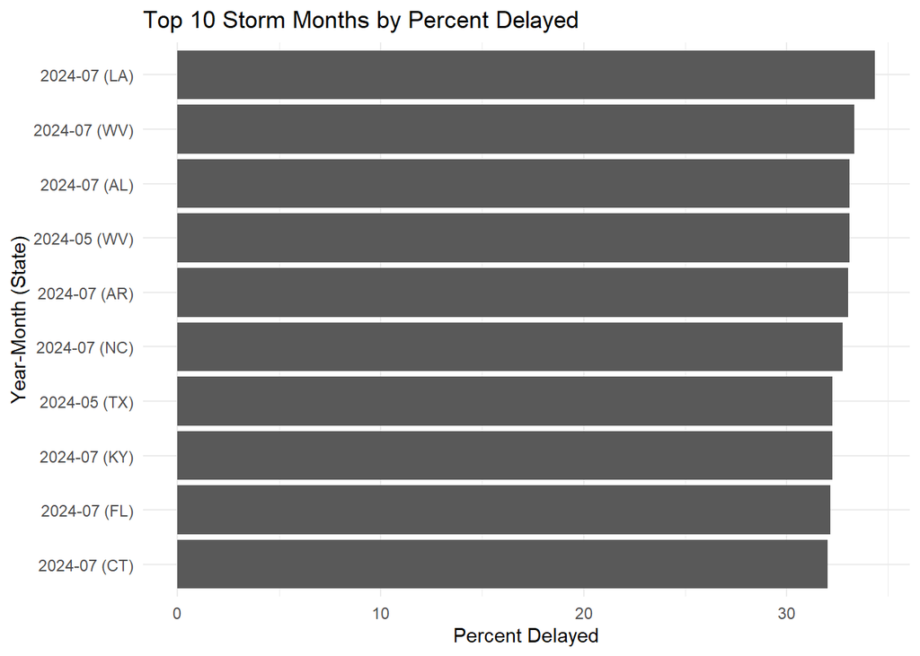

```r
library(ggplot2)
library(dplyr)

top10_plot_data <- top10_storm_months %>%
  mutate(
    pct_delayed = pct_delayed * 100,
    label = paste0(yr, "-", sprintf("%02d", mth), " (", state, ")")
  )

ggplot(top10_plot_data, aes(x = reorder(label, pct_delayed), y = pct_delayed)) +
  geom_col() +
  coord_flip() +
  labs(
    title = "Top 10 Storm Months by Percent Delayed",
    x = "Year-Month (State)",
    y = "Percent Delayed"
  ) +
  theme_minimal()
```

#### **Visualizing the Top 10 Storm Months**

This chart provides a clear comparison of the **10 storm months with the highest percentage of delayed flights**.  
We convert the delay rate to a percent and create labels combining year, month, and state.  
A horizontal bar chart helps highlight which storm periods experienced the most severe disruption.

```r
monthly_pattern <- final_joined_table %>%
  group_by(mth) %>%
  summarise(
    storms = sum(storm_events, na.rm = TRUE),
    flights = sum(total_flights, na.rm = TRUE),
    pct_delayed = round(sum(total_delayed, na.rm = TRUE) / flights, 4)
  ) %>%
  arrange(mth)

monthly_pattern
```

```
# A tibble: 12 × 4
     mth storms flights pct_delayed
   <int>  <dbl>   <dbl>       <dbl>
 1     1   8340  578286       0.231
 2     2   3493  549054       0.155
 3     3   3662  624524       0.202
 4     4   5450  615904       0.187
 5     5  10596  645230       0.256
 6     6   8157  647388       0.241
 7     7   8632  672260       0.283
 8     8   7359  656777       0.226
 9     9   3201  619009       0.153
10    10   1638  653338       0.129
11    11   2535  611017       0.145
12    12   2956  627398       0.209
```

#### **Monthly Storm and Delay Patterns**

This step summarizes the relationship between storms and airline delays at a **month-by-month level**.  
For each month, we calculate:

- the **total number of storm events**
- the **total number of flights**
- the **percentage of flights delayed**.

This creates a high-level view of how seasonal weather patterns align with nationwide flight delays.

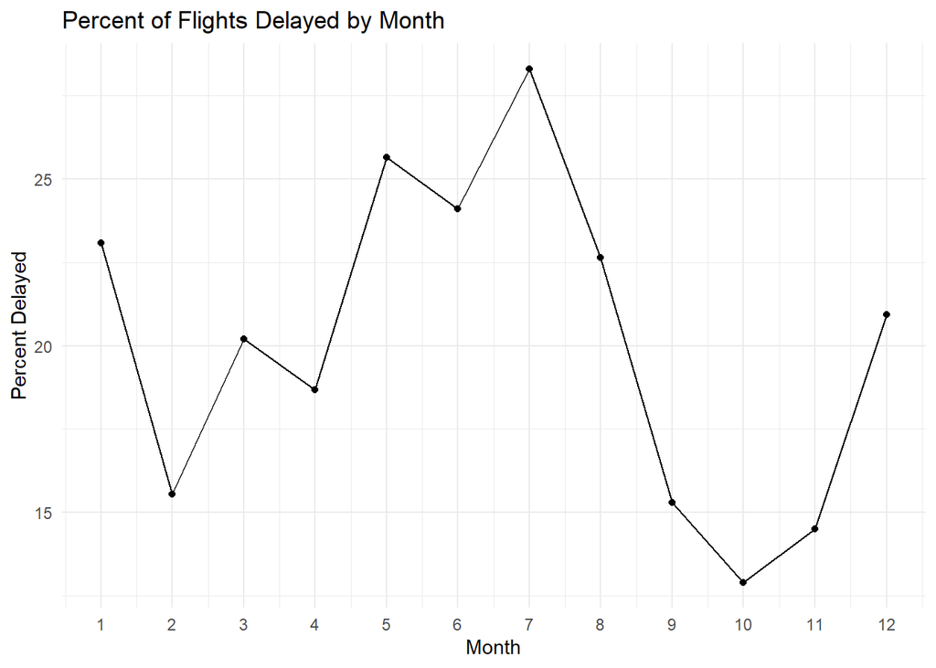

```r
library(ggplot2)
library(dplyr)

plot_data <- monthly_pattern %>%
  mutate(
    pct_delayed = pct_delayed * 100   # convert to percent
  )

# Line chart for monthly delay percentages
ggplot(plot_data, aes(x = mth, y = pct_delayed)) +
  geom_line() +
  geom_point() +
  labs(
    title = "Percent of Flights Delayed by Month",
    x = "Month",
    y = "Percent Delayed"
  ) +
  scale_x_continuous(breaks = 1:12) +
  theme_minimal()
```

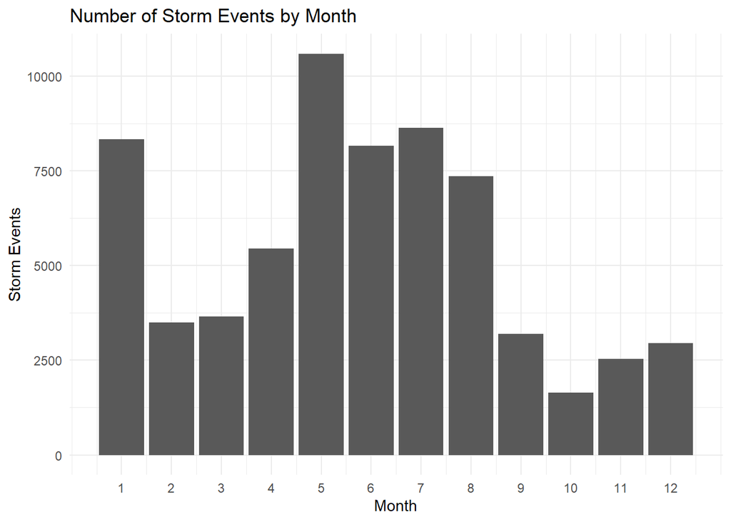

```r
# Bar chart for monthly storm counts
ggplot(plot_data, aes(x = mth, y = storms)) +
  geom_col() +
  labs(
    title = "Number of Storm Events by Month",
    x = "Month",
    y = "Storm Events"
  ) +
  scale_x_continuous(breaks = 1:12) +
  theme_minimal()
```

#### **Visualizing Monthly Storms and Delays**

To better understand seasonal patterns, we create two plots:

1. **Monthly Delay Rate**  
   A line chart showing the percentage of flights delayed each month.  
   This helps reveal which months experience the highest overall delays.
2. **Storm Frequency by Month**  
   A bar chart showing the number of storm events recorded each month.  
   Comparing this with the delay pattern highlights how closely weather aligns with airline disruptions.

Together, these visuals provide a clear picture of how storms and delays vary across the year.

```r
state_ranking_diff <- final_joined_table %>%
  group_by(state) %>%
  summarise(
    pct_delayed_storm = round(
      sum(ifelse(storm_flag == 1, total_delayed, 0), na.rm = TRUE) /
      sum(ifelse(storm_flag == 1, total_flights, 0), na.rm = TRUE),
      4
    ),
    pct_delayed_clear = round(
      sum(ifelse(storm_flag == 0, total_delayed, 0), na.rm = TRUE) /
      sum(ifelse(storm_flag == 0, total_flights, 0), na.rm = TRUE),
      4
    )
  ) %>%
  filter(!is.na(pct_delayed_clear)) %>%
  mutate(
    diff = pct_delayed_storm - pct_delayed_clear
  ) %>%
  arrange(desc(diff))

state_ranking_diff
```

```
# A tibble: 9 × 4
  state pct_delayed_storm pct_delayed_clear   diff
  <chr>             <dbl>             <dbl>  <dbl>
1 CT                0.246             0.148 0.0973
2 SC                0.203             0.126 0.0771
3 ME                0.202             0.129 0.0728
4 VT                0.204             0.136 0.0684
5 MA                0.233             0.168 0.0655
6 NC                0.216             0.156 0.0603
7 NH                0.214             0.154 0.0602
8 RI                0.231             0.190 0.0411
9 DC                0.218             0.181 0.0374
```

#### **State-Level Impact: Storm vs Clear Month Delays**

This step compares how each state’s delay rate changes during storm months.  
For every state, we calculate:

- Percent delayed in storm months
- Percent delayed in clear months
- Difference between the two

States are then ranked by how much delays increase when storms occur.  
This highlights where weather has the strongest operational impact on aviation.

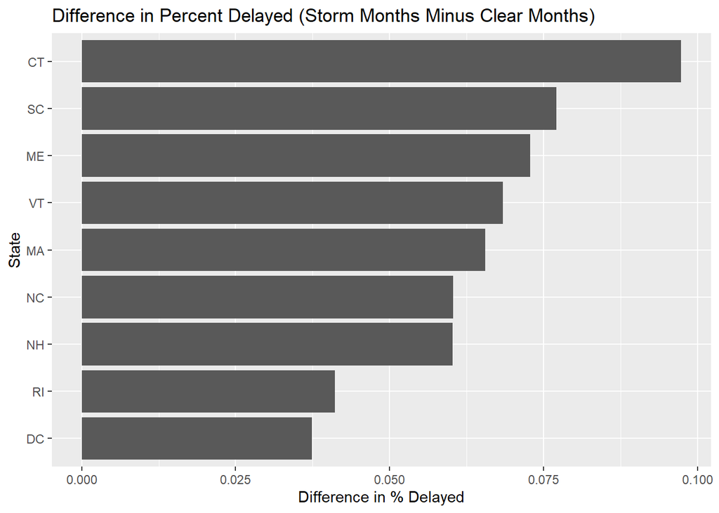

```r
library(ggplot2)

ggplot(state_ranking_diff, aes(x = reorder(state, diff), y = diff)) +
  geom_col() +
  coord_flip() +
  labs(
    title = "Difference in Percent Delayed (Storm Months Minus Clear Months)",
    x = "State",
    y = "Difference in % Delayed"
  )
```

#### **Visualization: States with the Largest Storm Delay Impact**

This bar chart shows how much each state’s percent of delayed flights increases during storm months compared to clear months.  
By ordering states by the size of this difference, the plot highlights where storms have the strongest relative effect on flight operations.

```r
delay_cause_summary <- final_joined_table %>%
  group_by(storm_flag) %>%
  summarise(
    weather_delay_mins = sum(weather_delay_mins, na.rm = TRUE),
    carrier_delay_mins = sum(carrier_delay_mins, na.rm = TRUE),
    total_delay_mins   = sum(total_delay_mins,   na.rm = TRUE)
  ) %>%
  arrange(storm_flag)

delay_cause_summary
```

```
# A tibble: 2 × 4
  storm_flag weather_delay_mins carrier_delay_mins total_delay_mins
       <dbl>              <dbl>              <dbl>            <dbl>
1          0              62698             573295          1607447
2          1            6692530           36803184        108037714
```

#### **Summary of Delay Causes During Storm vs Clear Months**

This summary compares how much total delay time comes from different causes in storm months versus clear months.  
By aggregating weather delays, carrier delays, and total delay minutes, we can see how storms shift the overall composition of delay sources.

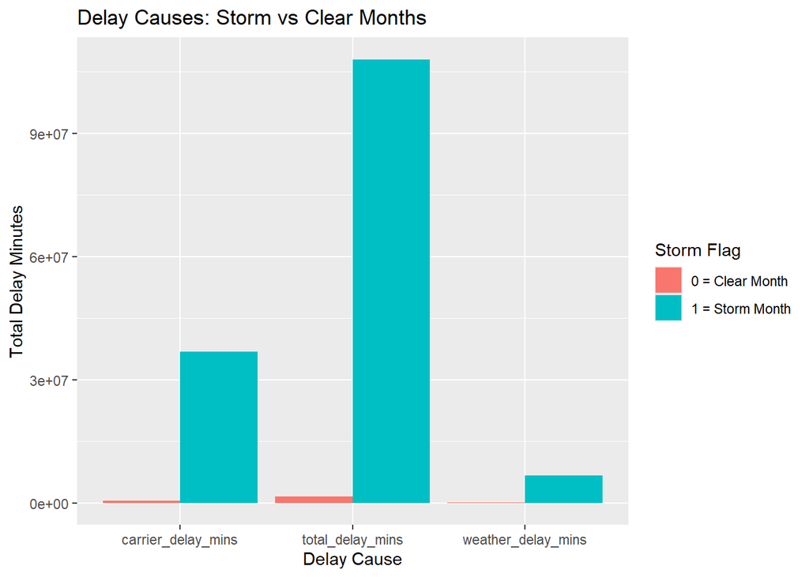

```r
library(tidyr)
library(ggplot2)

delay_plot_data <- delay_cause_summary %>%
  pivot_longer(
    cols = c(weather_delay_mins, carrier_delay_mins, total_delay_mins),
    names_to = "cause",
    values_to = "minutes"
  )

ggplot(delay_plot_data, aes(x = cause, y = minutes, fill = factor(storm_flag))) +
  geom_col(position = "dodge") +
  scale_fill_discrete(
    name = "Storm Flag",
    labels = c("0 = Clear Month", "1 = Storm Month")
  ) +
  labs(
    title = "Delay Causes: Storm vs Clear Months",
    x = "Delay Cause",
    y = "Total Delay Minutes"
  )
```

#### **Visualizing Delay Causes Across Storm and Clear Months**

This plot compares total delay minutes from three sources — weather delays, carrier delays, and overall delays — separated by storm vs clear months.  
By reshaping the data into a long format, we can easily visualize how each delay type increases during storm periods.